# Επιχειρηματική Αναλυτική: Ανάλυση Kickstarter Projects

Όμηρος Λούπης - iis23088

2026-03-23

# 1 Εισαγωγή

## 1.1 Φόρτωση Βιβλιοθηκών

```r
# Εγκατάσταση πακέτων (αν δεν υπάρχουν ήδη)
# install.packages(c("tidyverse", "corrplot", "scales", "knitr", "kableExtra"))

library(tidyverse)   # Περιλαμβάνει ggplot2, dplyr, readr κ.λπ.
library(corrplot)    # Πίνακας συσχετίσεων
library(scales)      # Μορφοποίηση αξόνων
library(knitr)       # Πίνακες σε Markdown
library(kableExtra)  # Βελτιωμένοι πίνακες
```

## 1.2 Φόρτωση Δεδομένων

```r
# Φόρτωση του dataset — αλλάξτε το path ανάλογα με τη θέση του αρχείου σας
df <- read_csv("ks-projects-201801.csv")

# Πρώτη ματιά στα δεδομένα
glimpse(df)
```

```
## Rows: 378,661
## Columns: 15
## $ ID               <dbl> 1000002330, 1000003930, 1000004038, 1000007540, 10000…
## $ name             <chr> "The Songs of Adelaide & Abullah", "Greeting From Ear…
## $ category         <chr> "Poetry", "Narrative Film", "Narrative Film", "Music"…
## $ main_category    <chr> "Publishing", "Film & Video", "Film & Video", "Music"…
## $ currency         <chr> "GBP", "USD", "USD", "USD", "USD", "USD", "USD", "USD…
## $ deadline         <date> 2015-10-09, 2017-11-01, 2013-02-26, 2012-04-16, 2015…
## $ goal             <dbl> 1000, 30000, 45000, 5000, 19500, 50000, 1000, 25000, …
## $ launched         <dttm> 2015-08-11 12:12:28, 2017-09-02 04:43:57, 2013-01-12…
## $ pledged          <dbl> 0.00, 2421.00, 220.00, 1.00, 1283.00, 52375.00, 1205.…
## $ state            <chr> "failed", "failed", "failed", "failed", "canceled", "…
## $ backers          <dbl> 0, 15, 3, 1, 14, 224, 16, 40, 58, 43, 0, 100, 0, 0, 7…
## $ country          <chr> "GB", "US", "US", "US", "US", "US", "US", "US", "US",…
## $ `usd pledged`    <dbl> 0.00, 100.00, 220.00, 1.00, 1283.00, 52375.00, 1205.0…
## $ usd_pledged_real <dbl> 0.00, 2421.00, 220.00, 1.00, 1283.00, 52375.00, 1205.…
## $ usd_goal_real    <dbl> 1533.95, 30000.00, 45000.00, 5000.00, 19500.00, 50000…
```

# 2 Περιγραφή του Dataset και της Πηγής

## 2.1 Πηγή Δεδομένων

Το dataset **“Kickstarter Projects”** προέρχεται από την πλατφόρμα [Kaggle](https://www.kaggle.com/datasets/kemical/kickstarter-projects) και δημιουργήθηκε από τον χρήστη *Mickaël Mouillé*. Περιέχει πληροφορίες για περισσότερα από **378.000 projects** που δημοσιεύθηκαν στην πλατφόρμα crowdfunding Kickstarter μέχρι τον Ιανουάριο 2018.

Το **Kickstarter** είναι μια από τις μεγαλύτερες πλατφόρμες crowdfunding παγκοσμίως. Οι δημιουργοί (creators) δημοσιεύουν projects με έναν στόχο χρηματοδότησης (goal) και μια προθεσμία (deadline). Αν το ποσό που συγκεντρώνεται από τους υποστηρικτές (backers) ξεπεράσει τον στόχο, το project θεωρείται επιτυχημένο — αλλιώς αποτυγχάνει (μοντέλο “all-or-nothing”).

## 2.2 Αιτιολόγηση Επιλογής

Η επιλογή αυτού του dataset είναι ιδιαίτερα κατάλληλη για το μάθημα της **Επιχειρηματικής Αναλυτικής** για τους εξής λόγους:

- **Επιχειρηματική συνάφεια:** Το crowdfunding αποτελεί σύγχρονο μοντέλο χρηματοδότησης νεοφυών επιχειρήσεων και δημιουργικών projects.
- **Πλούσιες μεταβλητές:** Συνδυάζει αριθμητικά και κατηγορικά δεδομένα, κατάλληλα για πολύπλευρη ανάλυση.
- **Αποφάσεις βασισμένες σε δεδομένα:** Η ανάλυση μπορεί να οδηγήσει σε πρακτικά συμπεράσματα για τη στρατηγική δημιουργίας ενός crowdfunding campaign.
- **Μεγάλο μέγεθος δείγματος:** Πάνω από 378.000 εγγραφές εξασφαλίζουν στατιστικά αξιόπιστα αποτελέσματα.

## 2.3 Πιθανά Επιχειρηματικά Ερωτήματα

1. **Ποιοι παράγοντες συμβάλλουν στην επιτυχία ενός Kickstarter project;** (π.χ. κατηγορία, ύψος στόχου, χώρα προέλευσης)
2. **Ποια είναι η σχέση μεταξύ του στόχου χρηματοδότησης (goal) και του ποσού που συγκεντρώνεται (pledged);**
3. **Ποιες κατηγορίες projects έχουν τα υψηλότερα ποσοστά επιτυχίας;**
4. **Πώς επηρεάζει ο αριθμός των υποστηρικτών (backers) την τελική χρηματοδότηση;**
5. **Υπάρχει βέλτιστο εύρος στόχου χρηματοδότησης που μεγιστοποιεί τις πιθανότητες επιτυχίας;**

# 3 Προετοιμασία Δεδομένων

```r
# Μετονομασία στηλών για ευκολία
colnames(df) <- c("ID", "name", "category", "main_category", "currency",
                   "deadline", "goal", "launched", "pledged", "state",
                   "backers", "country", "usd_pledged", "usd_pledged_real",
                   "usd_goal_real")

# Μετατροπή ημερομηνιών
# Η στήλη deadline είναι σε μορφή "YYYY-MM-DD" και η launched σε "YYYY-MM-DD HH:MM:SS"
df$deadline <- as.Date(df$deadline)
df$launched <- as.Date(as.character(df$launched))

# Υπολογισμός διάρκειας campaign σε ημέρες
df$duration_days <- as.numeric(df$deadline - df$launched)

# Υπολογισμός ποσοστού χρηματοδότησης (funding ratio)
df$funding_ratio <- ifelse(df$usd_goal_real > 0,
                           df$usd_pledged_real / df$usd_goal_real, NA)

# Δημιουργία δυαδικής μεταβλητής επιτυχίας
df$success <- ifelse(df$state == "successful", 1, 0)

# Αφαίρεση projects με κατάσταση "live" ή "undefined"
df_clean <- df %>%
  filter(state %in% c("successful", "failed", "canceled", "suspended"))

# Αφαίρεση πιθανών αρνητικών/μηδενικών διαρκειών
df_clean <- df_clean %>%
  filter(duration_days > 0)

# Εμφάνιση δομής καθαρισμένου dataset
cat("Διαστάσεις καθαρισμένου dataset:", dim(df_clean), "\n")
```

```
## Διαστάσεις καθαρισμένου dataset: 372300 18
```

```r
head(df_clean) %>% kable(caption = "Πρώτες γραμμές του dataset") %>%
  kable_styling(bootstrap_options = c("striped", "hover"), full_width = FALSE)
```

Πρώτες γραμμές του dataset

| ID | name | category | main_category | currency | deadline | goal | launched | pledged | state | backers | country | usd_pledged | usd_pledged_real | usd_goal_real | duration_days | funding_ratio | success |
| --- | --- | --- | --- | --- | --- | --- | --- | --- | --- | --- | --- | --- | --- | --- | --- | --- | --- |
| 1000002330 | The Songs of Adelaide & Abullah | Poetry | Publishing | GBP | 2015-10-09 | 1000 | 2015-08-11 | 0 | failed | 0 | GB | 0 | 0 | 1533.95 | 59 | 0.0000000 | 0 |
| 1000003930 | Greeting From Earth: ZGAC Arts Capsule For ET | Narrative Film | Film & Video | USD | 2017-11-01 | 30000 | 2017-09-02 | 2421 | failed | 15 | US | 100 | 2421 | 30000.00 | 60 | 0.0807000 | 0 |
| 1000004038 | Where is Hank? | Narrative Film | Film & Video | USD | 2013-02-26 | 45000 | 2013-01-12 | 220 | failed | 3 | US | 220 | 220 | 45000.00 | 45 | 0.0048889 | 0 |
| 1000007540 | ToshiCapital Rekordz Needs Help to Complete Album | Music | Music | USD | 2012-04-16 | 5000 | 2012-03-17 | 1 | failed | 1 | US | 1 | 1 | 5000.00 | 30 | 0.0002000 | 0 |
| 1000011046 | Community Film Project: The Art of Neighborhood Filmmaking | Film & Video | Film & Video | USD | 2015-08-29 | 19500 | 2015-07-04 | 1283 | canceled | 14 | US | 1283 | 1283 | 19500.00 | 56 | 0.0657949 | 0 |
| 1000014025 | Monarch Espresso Bar | Restaurants | Food | USD | 2016-04-01 | 50000 | 2016-02-26 | 52375 | successful | 224 | US | 52375 | 52375 | 50000.00 | 35 | 1.0475000 | 1 |

# 4 Περιγραφή Μεταβλητών

Ο παρακάτω πίνακας παρουσιάζει τις μεταβλητές του dataset μαζί με τον τύπο τους, το εύρος τιμών και τη μονάδα μέτρησης:

```r
var_info <- data.frame(
  Μεταβλητή = c("ID", "name", "category", "main_category", "currency",
                 "deadline", "goal", "launched", "pledged", "state",
                 "backers", "country", "usd_pledged_real",
                 "usd_goal_real", "duration_days", "funding_ratio", "success"),
  Τύπος = c("Ακέραιος", "Κείμενο", "Κατηγορική", "Κατηγορική", "Κατηγορική",
             "Ημερομηνία", "Αριθμητική (συνεχής)", "Ημερομηνία",
             "Αριθμητική (συνεχής)", "Κατηγορική",
             "Ακέραιος (διακριτή)", "Κατηγορική", "Αριθμητική (συνεχής)",
             "Αριθμητική (συνεχής)", "Ακέραιος (διακριτή)",
             "Αριθμητική (συνεχής)", "Δυαδική (0/1)"),
  Μονάδα_Μέτρησης = c(
    "-", "-", "-", "-", "-",
    "YYYY-MM-DD", "Τοπικό νόμισμα", "YYYY-MM-DD", "Τοπικό νόμισμα", "-",
    "Άτομα", "-", "USD ($)",
    "USD ($)", "Ημέρες", "Αδιάστατος λόγος", "-"
  ),
  Περιγραφή = c(
    "Μοναδικό αναγνωριστικό project",
    "Όνομα του project",
    "Υποκατηγορία (π.χ. Documentary, Rock, Gadgets)",
    "Κύρια κατηγορία (π.χ. Film & Video, Music, Technology)",
    "Νόμισμα χρηματοδότησης (π.χ. USD, GBP, EUR)",
    "Προθεσμία χρηματοδότησης",
    "Στόχος χρηματοδότησης στο αρχικό νόμισμα",
    "Ημερομηνία εκκίνησης του campaign",
    "Ποσό που συγκεντρώθηκε στο αρχικό νόμισμα",
    "Κατάσταση: successful, failed, canceled, suspended",
    "Αριθμός υποστηρικτών (backers)",
    "Χώρα προέλευσης (π.χ. US, GB, CA)",
    "Ποσό σε USD (μετατροπή μέσω fixer.io API)",
    "Στόχος σε USD (μετατροπή μέσω fixer.io API)",
    "Διάρκεια campaign (deadline − launched)",
    "Λόγος χρηματοδότησης (pledged / goal σε USD)",
    "1 = Επιτυχές, 0 = Μη επιτυχές"
  )
)

var_info %>%
  kable(caption = "Περιγραφή μεταβλητών του dataset",
        col.names = c("Μεταβλητή", "Τύπος", "Μονάδα Μέτρησης", "Περιγραφή")) %>%
  kable_styling(bootstrap_options = c("striped", "hover", "condensed"), full_width = TRUE) %>%
  column_spec(1, bold = TRUE)
```

Περιγραφή μεταβλητών του dataset

Μεταβλητή

Τύπος

Μονάδα Μέτρησης

Περιγραφή

ID

Ακέραιος

Μοναδικό αναγνωριστικό project

name

Κείμενο

Όνομα του project

category

Κατηγορική

Υποκατηγορία (π.χ. Documentary, Rock, Gadgets)

main_category

Κατηγορική

Κύρια κατηγορία (π.χ. Film & Video, Music, Technology)

currency

Κατηγορική

Νόμισμα χρηματοδότησης (π.χ. USD, GBP, EUR)

deadline

Ημερομηνία

YYYY-MM-DD

Προθεσμία χρηματοδότησης

goal

Αριθμητική (συνεχής)

Τοπικό νόμισμα

Στόχος χρηματοδότησης στο αρχικό νόμισμα

launched

Ημερομηνία

YYYY-MM-DD

Ημερομηνία εκκίνησης του campaign

pledged

Αριθμητική (συνεχής)

Τοπικό νόμισμα

Ποσό που συγκεντρώθηκε στο αρχικό νόμισμα

state

Κατηγορική

Κατάσταση: successful, failed, canceled, suspended

backers

Ακέραιος (διακριτή)

Άτομα

Αριθμός υποστηρικτών (backers)

country

Κατηγορική

Χώρα προέλευσης (π.χ. US, GB, CA)

usd_pledged_real

Αριθμητική (συνεχής)

duration_days

Ακέραιος (διακριτή)

Ημέρες

Διάρκεια campaign (deadline − launched)

funding_ratio

Αριθμητική (συνεχής)

Αδιάστατος λόγος

Λόγος χρηματοδότησης (pledged / goal σε USD)

success

Δυαδική (0/1)

1 = Επιτυχές, 0 = Μη επιτυχές

```r
# Σύνοψη αριθμητικών μεταβλητών
summary(df_clean %>%
          select(goal, pledged, backers, usd_pledged_real,
                 usd_goal_real, duration_days, funding_ratio))
```

```
##       goal             pledged            backers         usd_pledged_real
##  Min.   :0.00e+00   Min.   :       0   Min.   :     0.0   Min.   :0.000e+00
##  1st Qu.:2.00e+03   1st Qu.:      31   1st Qu.:     2.0   1st Qu.:3.120e+01
##  Median :5.50e+03   Median :     625   Median :    12.0   Median :6.280e+02
##  Mean   :4.93e+04   Mean   :    9758   Mean   :   106.9   Mean   :9.148e+03
##  3rd Qu.:1.65e+04   3rd Qu.:    4092   3rd Qu.:    57.0   3rd Qu.:4.066e+03
##  Max.   :1.00e+08   Max.   :20338986   Max.   :219382.0   Max.   :2.034e+07
##  usd_goal_real       duration_days      funding_ratio
##  Min.   :        0   Min.   :    1.00   Min.   :0.000e+00
##  1st Qu.:     2000   1st Qu.:   30.00   1st Qu.:5.000e-03
##  Median :     5500   Median :   30.00   Median :1.350e-01
##  Mean   :    45722   Mean   :   34.46   Mean   :3.264e+00
##  3rd Qu.:    15985   3rd Qu.:   37.00   3rd Qu.:1.066e+00
##  Max.   :166361391   Max.   :16739.00   Max.   :1.043e+05
```

```r
# Κατανομή κατηγορικών μεταβλητών
cat("=== Κατανομή State ===\n")
```

```
## === Κατανομή State ===
```

```r
table(df_clean$state)
```

```
##
##   canceled     failed successful  suspended
##      38779     197719     133956       1846
```

```r
cat("\n=== Κατανομή Main Category (Top 10) ===\n")
```

```
##
## === Κατανομή Main Category (Top 10) ===
```

```r
sort(table(df_clean$main_category), decreasing = TRUE)[1:10]
```

```
##
## Film & Video        Music   Publishing        Games   Technology       Design
##        62399        49403        39113        34943        32189        29763
##          Art         Food      Fashion      Theater
##        27959        24418        22563        10871
```

```r
cat("\n=== Κατανομή Country (Top 10) ===\n")
```

```
##
## === Κατανομή Country (Top 10) ===
```

```r
sort(table(df_clean$country), decreasing = TRUE)[1:10]
```

```
##
##     US     GB     CA     AU     DE     FR     NL     IT     ES     SE
## 290887  33393  14624   7769   4096   2887   2833   2802   2224   1737
```

# 5 Περιγραφικά Στατιστικά

## 5.1 Μέτρα Κεντρικής Τάσης

Υπολογίζουμε τον **μέσο όρο**, τη **διάμεσο** και την **επικρατούσα τιμή** (mode) για τις βασικές αριθμητικές μεταβλητές.

```r
# Συνάρτηση υπολογισμού mode (η R δεν έχει ενσωματωμένη)
calc_mode <- function(x) {
  x <- na.omit(x)
  ux <- unique(x)
  ux[which.max(tabulate(match(x, ux)))]
}

# Επιλογή αριθμητικών μεταβλητών
numeric_vars <- c("usd_goal_real", "usd_pledged_real", "backers",
                   "duration_days", "funding_ratio")

central_stats <- data.frame(
  Μεταβλητή = numeric_vars,
  Μέσος_Όρος = sapply(numeric_vars, function(v)
    round(mean(df_clean[[v]], na.rm = TRUE), 2)),
  Διάμεσος = sapply(numeric_vars, function(v)
    round(median(df_clean[[v]], na.rm = TRUE), 2)),
  Επικρατούσα_Τιμή = sapply(numeric_vars, function(v)
    round(calc_mode(df_clean[[v]]), 2))
)
rownames(central_stats) <- NULL

central_stats %>%
  kable(caption = "Μέτρα Κεντρικής Τάσης",
        col.names = c("Μεταβλητή", "Μέσος Όρος", "Διάμεσος",
                       "Επικρατούσα Τιμή (Mode)")) %>%
  kable_styling(bootstrap_options = c("striped", "hover"), full_width = FALSE)
```

Μέτρα Κεντρικής Τάσης

| Μεταβλητή | Μέσος Όρος | Διάμεσος | Επικρατούσα Τιμή (Mode) |
| --- | --- | --- | --- |
| usd_goal_real | 45721.62 | 5500.00 | 5000 |
| usd_pledged_real | 9148.41 | 628.00 | 0 |
| backers | 106.91 | 12.00 | 0 |
| duration_days | 34.46 | 30.00 | 30 |
| funding_ratio | 3.26 | 0.14 | 0 |

**Σχολιασμός:** Παρατηρούμε σημαντική διαφορά μεταξύ μέσου όρου και διαμέσου, ιδιαίτερα στις μεταβλητές `usd_goal_real` και `usd_pledged_real`. Αυτό υποδεικνύει ότι οι κατανομές είναι **έντονα θετικά ασύμμετρες** (right-skewed), με λίγα projects να έχουν πολύ υψηλούς στόχους ή χρηματοδοτήσεις που ανεβάζουν τον μέσο όρο. Η διάμεσος αποτελεί πιο αξιόπιστο μέτρο κεντρικής τάσης σε αυτή την περίπτωση.

## 5.2 Μέτρα Διασποράς

```r
dispersion_stats <- data.frame(
  Μεταβλητή = numeric_vars,
  Τυπική_Απόκλιση = sapply(numeric_vars, function(v)
    format(round(sd(df_clean[[v]], na.rm = TRUE), 2),
           big.mark = ",", scientific = FALSE)),
  Διακύμανση = sapply(numeric_vars, function(v)
    format(round(var(df_clean[[v]], na.rm = TRUE), 2),
           big.mark = ",", scientific = FALSE)),
  Ελάχιστο = sapply(numeric_vars, function(v)
    round(min(df_clean[[v]], na.rm = TRUE), 2)),
  Μέγιστο = sapply(numeric_vars, function(v)
    format(round(max(df_clean[[v]], na.rm = TRUE), 2),
           big.mark = ",", scientific = FALSE)),
  Εύρος = sapply(numeric_vars, function(v)
    format(round(max(df_clean[[v]], na.rm = TRUE) -
                   min(df_clean[[v]], na.rm = TRUE), 2),
           big.mark = ",", scientific = FALSE))
)
rownames(dispersion_stats) <- NULL

dispersion_stats %>%
  kable(caption = "Μέτρα Διασποράς",
        col.names = c("Μεταβλητή", "Τυπική Απόκλιση", "Διακύμανση",
                       "Ελάχιστο", "Μέγιστο", "Εύρος")) %>%
  kable_styling(bootstrap_options = c("striped", "hover"), full_width = FALSE)
```

Μέτρα Διασποράς

| Μεταβλητή | Τυπική Απόκλιση | Διακύμανση | Ελάχιστο | Μέγιστο | Εύρος |
| --- | --- | --- | --- | --- | --- |
| usd_goal_real | 1,151,326 | 1,325,552,342,251 | 0.01 | 166,361,391 | 166,361,391 |
| usd_pledged_real | 91,703.45 | 8,409,523,473 | 0.00 | 20,338,986 | 20,338,986 |
| backers | 914.24 | 835,827.1 | 0.00 | 219,382 | 219,382 |
| duration_days | 66.45 | 4,415.45 | 1.00 | 16,739 | 16,738 |
| funding_ratio | 269.08 | 72,403.5 | 0.00 | 104,277.9 | 104,277.9 |

**Σχολιασμός:** Η πολύ υψηλή τυπική απόκλιση σε σχέση με τον μέσο όρο (ιδιαίτερα στο `usd_pledged_real` και `usd_goal_real`) επιβεβαιώνει τη μεγάλη ετερογένεια των projects στην πλατφόρμα — από μικρά ατομικά projects μέχρι μεγάλα εγχειρήματα εκατομμυρίων δολαρίων. Ο υψηλός συντελεστής μεταβλητότητας (CV = SD / Mean) υποδεικνύει ότι οι τιμές διαφοροποιούνται δραματικά γύρω από τον μέσο.

# 6 Διερεύνηση Συσχετίσεων

## 6.1 Πίνακας Συσχετίσεων

```r
# Επιλογή αριθμητικών μεταβλητών για τον πίνακα συσχετίσεων
cor_vars <- c("usd_goal_real", "usd_pledged_real", "backers",
              "duration_days", "funding_ratio", "success")

cor_matrix <- cor(df_clean[, cor_vars], use = "complete.obs")

# Εμφάνιση πίνακα
round(cor_matrix, 3) %>%
  kable(caption = "Πίνακας Συσχετίσεων (Pearson)") %>%
  kable_styling(bootstrap_options = c("striped", "hover"), full_width = FALSE)
```

Πίνακας Συσχετίσεων (Pearson)

|  | usd_goal_real | usd_pledged_real | backers | duration_days | funding_ratio | success |
| --- | --- | --- | --- | --- | --- | --- |
| usd_goal_real | 1.000 | 0.006 | 0.005 | 0.004 | 0.000 | -0.024 |
| usd_pledged_real | 0.006 | 1.000 | 0.752 | 0.001 | 0.009 | 0.111 |
| backers | 0.005 | 0.752 | 1.000 | -0.001 | 0.017 | 0.129 |
| duration_days | 0.004 | 0.001 | -0.001 | 1.000 | 0.000 | -0.026 |
| funding_ratio | 0.000 | 0.009 | 0.017 | 0.000 | 1.000 | 0.015 |
| success | -0.024 | 0.111 | 0.129 | -0.026 | 0.015 | 1.000 |

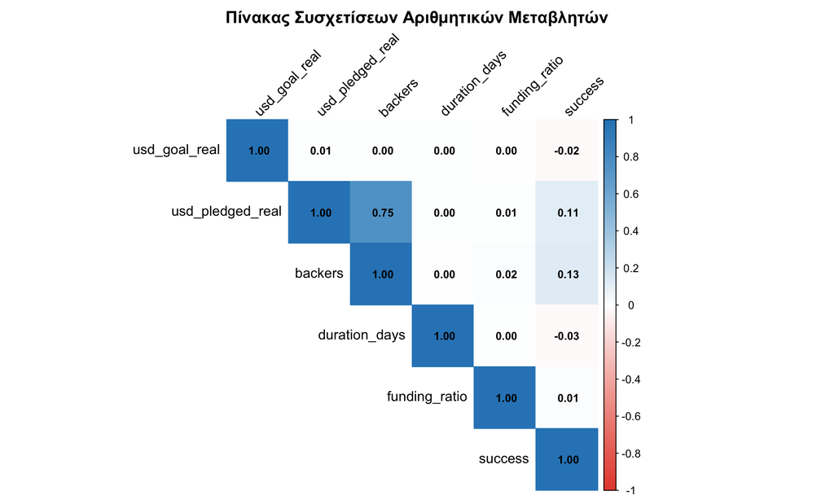

Οπτικοποίηση πίνακα συσχετίσεων

```r
corrplot(cor_matrix,
         method = "color",
         type = "upper",
         addCoef.col = "black",
         number.cex = 0.8,
         tl.col = "black",
         tl.srt = 45,
         col = colorRampPalette(c("#E74C3C", "white", "#2E86C1"))(200),
         title = "Πίνακας Συσχετίσεων Αριθμητικών Μεταβλητών",
         mar = c(0, 0, 2, 0))
```

## 6.2 Ερμηνεία Συσχετίσεων

```r
# Εμφάνιση σημαντικότερων συσχετίσεων
cor_df <- as.data.frame(as.table(cor_matrix))
names(cor_df) <- c("Μεταβλητή_1", "Μεταβλητή_2", "Συσχέτιση")

# Φιλτράρισμα: χωρίς διαγώνια, μοναδικά ζεύγη, ταξινομημένα κατά |r|
cor_df <- cor_df %>%
  filter(as.character(Μεταβλητή_1) < as.character(Μεταβλητή_2)) %>%
  arrange(desc(abs(Συσχέτιση)))

cor_df %>%
  mutate(
    Συσχέτιση = round(Συσχέτιση, 3),
    Ένταση = case_when(
      abs(Συσχέτιση) >= 0.7 ~ "Ισχυρή",
      abs(Συσχέτιση) >= 0.4 ~ "Μέτρια",
      abs(Συσχέτιση) >= 0.2 ~ "Ασθενής",
      TRUE ~ "Αμελητέα"
    )
  ) %>%
  kable(caption = "Ζεύγη μεταβλητών ταξινομημένα κατά απόλυτη συσχέτιση") %>%
  kable_styling(bootstrap_options = c("striped", "hover"), full_width = FALSE)
```

Ζεύγη μεταβλητών ταξινομημένα κατά απόλυτη συσχέτιση

| Μεταβλητή_1 | Μεταβλητή_2 | Συσχέτιση | Ένταση |
| --- | --- | --- | --- |
| backers | usd_pledged_real | 0.752 | Ισχυρή |
| backers | success | 0.129 | Αμελητέα |
| success | usd_pledged_real | 0.111 | Αμελητέα |
| duration_days | success | -0.026 | Αμελητέα |
| success | usd_goal_real | -0.024 | Αμελητέα |
| backers | funding_ratio | 0.017 | Αμελητέα |
| funding_ratio | success | 0.015 | Αμελητέα |
| funding_ratio | usd_pledged_real | 0.009 | Αμελητέα |
| usd_goal_real | usd_pledged_real | 0.006 | Αμελητέα |
| backers | usd_goal_real | 0.005 | Αμελητέα |
| duration_days | usd_goal_real | 0.004 | Αμελητέα |
| duration_days | usd_pledged_real | 0.001 | Αμελητέα |
| backers | duration_days | -0.001 | Αμελητέα |
| funding_ratio | usd_goal_real | 0.000 | Αμελητέα |
| duration_days | funding_ratio | 0.000 | Αμελητέα |

**Ερμηνεία:**

- **`backers` ↔︎ `usd_pledged_real`:** Αναμένεται ισχυρή θετική συσχέτιση — περισσότεροι υποστηρικτές σημαίνουν μεγαλύτερο ποσό χρηματοδότησης.
- **`funding_ratio` ↔︎ `success`:** Θετική συσχέτιση — τα επιτυχημένα projects ξεπερνούν τον στόχο τους (ratio > 1).
- **`backers` ↔︎ `success`:** Θετική συσχέτιση — τα επιτυχημένα projects προσελκύουν σημαντικά περισσότερους υποστηρικτές.
- **`usd_goal_real` ↔︎ `success`:** Αναμένεται αρνητική συσχέτιση — projects με πολύ υψηλούς στόχους τείνουν να αποτυγχάνουν συχνότερα.
- **`duration_days`:** Η διάρκεια του campaign δεν φαίνεται να σχετίζεται ισχυρά με καμία άλλη μεταβλητή.

# 7 Διαγράμματα

## 7.1 Scatterplot: Στόχος vs Χρηματοδότηση

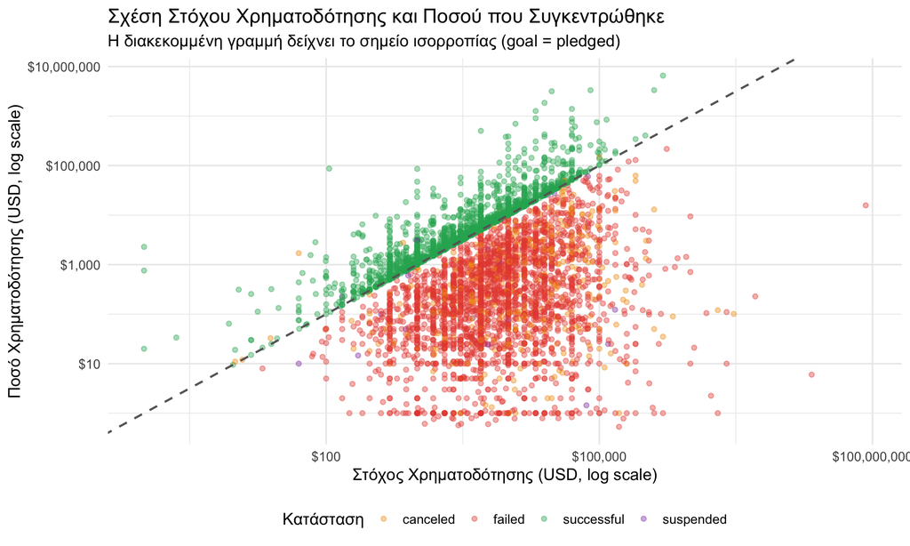

Scatterplot: Στόχος χρηματοδότησης vs Ποσό που συγκεντρώθηκε (σε USD)

```r
# Χρησιμοποιούμε δείγμα και log scale λόγω μεγάλου εύρους τιμών
# Φιλτράρουμε τιμές > 0 αφού χρησιμοποιούμε λογαριθμική κλίμακα
set.seed(42)
df_sample <- df_clean %>%
  filter(usd_goal_real > 0, usd_pledged_real > 0) %>%
  slice_sample(n = 5000)

ggplot(df_sample, aes(x = usd_goal_real, y = usd_pledged_real, color = state)) +
  geom_point(alpha = 0.4, size = 1.5) +
  scale_x_log10(labels = dollar_format()) +
  scale_y_log10(labels = dollar_format()) +
  geom_abline(intercept = 0, slope = 1, linetype = "dashed",
              color = "gray40", linewidth = 0.8) +
  labs(
    title = "Σχέση Στόχου Χρηματοδότησης και Ποσού που Συγκεντρώθηκε",
    subtitle = "Η διακεκομμένη γραμμή δείχνει το σημείο ισορροπίας (goal = pledged)",
    x = "Στόχος Χρηματοδότησης (USD, log scale)",
    y = "Ποσό Χρηματοδότησης (USD, log scale)",
    color = "Κατάσταση"
  ) +
  scale_color_manual(values = c("successful" = "#27AE60", "failed" = "#E74C3C",
                                "canceled" = "#F39C12", "suspended" = "#8E44AD")) +
  theme_minimal(base_size = 13) +
  theme(legend.position = "bottom")
```

**Σχολιασμός:** Το scatterplot αποκαλύπτει ένα ξεκάθαρο μοτίβο: τα **επιτυχημένα projects** (πράσινα) βρίσκονται κυρίως **πάνω από τη διακεκομμένη γραμμή** (δηλαδή συγκέντρωσαν περισσότερα από τον στόχο τους), ενώ τα **αποτυχημένα** (κόκκινα) βρίσκονται κάτω από αυτή. Επίσης, παρατηρούμε ότι τα projects με πιο χαμηλούς στόχους τείνουν να πετυχαίνουν συχνότερα.

## 7.2 Boxplot: Αριθμός Υποστηρικτών ανά Κατηγορία

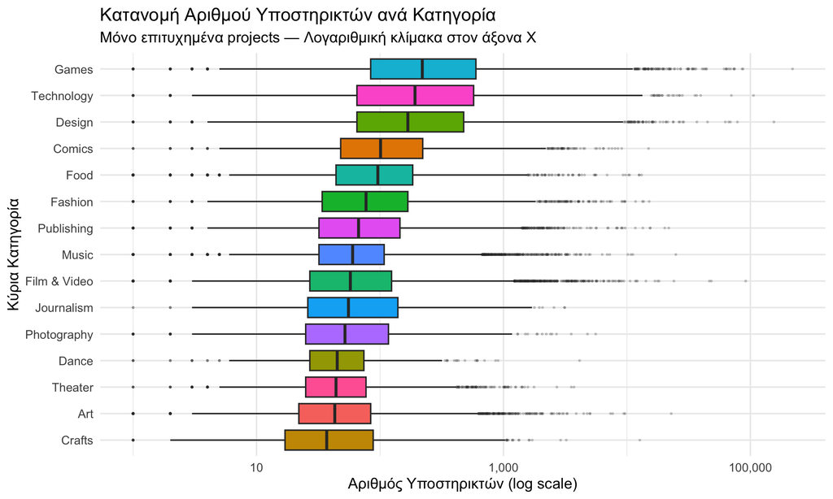

Boxplot: Αριθμός υποστηρικτών ανά κύρια κατηγορία (μόνο επιτυχημένα projects)

```r
# Φιλτράρουμε μόνο επιτυχημένα projects για πιο ουσιαστική σύγκριση
df_successful <- df_clean %>%
  filter(state == "successful", backers > 0)

ggplot(df_successful, aes(x = reorder(main_category, backers, FUN = median),
                           y = backers, fill = main_category)) +
  geom_boxplot(outlier.alpha = 0.2, outlier.size = 0.5) +
  coord_flip() +
  scale_y_log10(labels = comma_format()) +
  labs(
    title = "Κατανομή Αριθμού Υποστηρικτών ανά Κατηγορία",
    subtitle = "Μόνο επιτυχημένα projects — Λογαριθμική κλίμακα στον άξονα X",
    x = "Κύρια Κατηγορία",
    y = "Αριθμός Υποστηρικτών (log scale)"
  ) +
  theme_minimal(base_size = 13) +
  theme(legend.position = "none")
```

## 7.3 Histogram: Κατανομή Στόχου Χρηματοδότησης

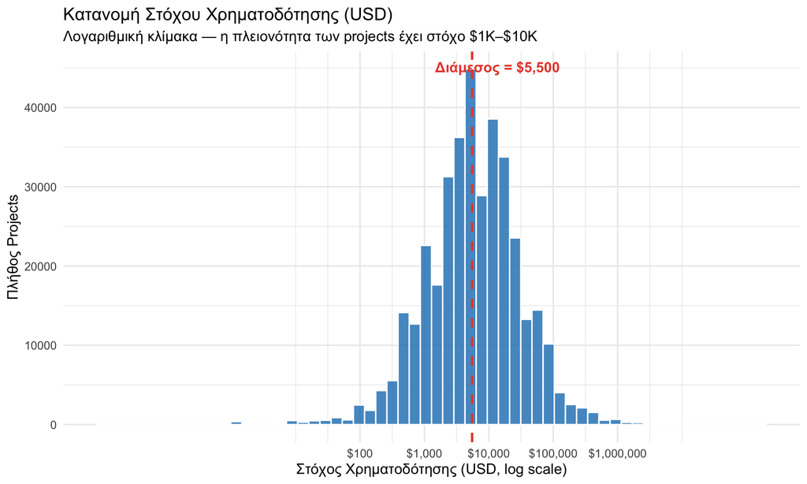

Histogram: Κατανομή στόχου χρηματοδότησης σε USD

```r
# Φιλτράρουμε τιμές > 0 για τη λογαριθμική κλίμακα
df_hist <- df_clean %>% filter(usd_goal_real > 0)

median_goal <- median(df_hist$usd_goal_real, na.rm = TRUE)

ggplot(df_hist, aes(x = usd_goal_real)) +
  geom_histogram(bins = 60, fill = "#2E86C1", color = "white", alpha = 0.85) +
  scale_x_log10(labels = dollar_format(),
                breaks = c(100, 1000, 10000, 100000, 1000000)) +
  labs(
    title = "Κατανομή Στόχου Χρηματοδότησης (USD)",
    subtitle = "Λογαριθμική κλίμακα — η πλειονότητα των projects έχει στόχο $1K–$10K",
    x = "Στόχος Χρηματοδότησης (USD, log scale)",
    y = "Πλήθος Projects"
  ) +
  theme_minimal(base_size = 13) +
  geom_vline(xintercept = median_goal,
             color = "#E74C3C", linetype = "dashed", linewidth = 1) +
  annotate("text", x = median_goal * 2.5, y = Inf,
           label = paste0("Διάμεσος = $", comma(median_goal)),
           vjust = 2, color = "#E74C3C", size = 4.5, fontface = "bold")
```

**Σχολιασμός:** Το histogram (σε λογαριθμική κλίμακα) δείχνει ότι η πλειονότητα των Kickstarter projects θέτει στόχους χρηματοδότησης στην περιοχή **$1.000–$10.000**. Η κατανομή είναι **θετικά ασύμμετρη**: υπάρχει μια μακριά ουρά στα δεξιά που αντιπροσωπεύει projects με πολύ φιλόδοξους στόχους (>$100K). Η κόκκινη διακεκομμένη γραμμή υποδεικνύει τη διάμεσο.

## 7.4 Bar Chart: Ποσοστό Επιτυχίας ανά Κύρια Κατηγορία

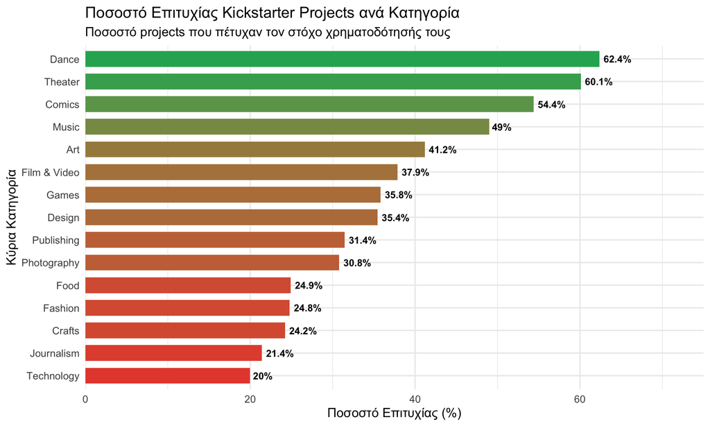

Bar Chart: Ποσοστό επιτυχίας ανά κύρια κατηγορία

```r
success_rate <- df_clean %>%
  group_by(main_category) %>%
  summarise(
    total = n(),
    successful = sum(state == "successful"),
    rate = successful / total * 100,
    .groups = "drop"
  ) %>%
  arrange(desc(rate))

ggplot(success_rate, aes(x = reorder(main_category, rate),
                          y = rate, fill = rate)) +
  geom_col(width = 0.7) +
  geom_text(aes(label = paste0(round(rate, 1), "%")),
            hjust = -0.15, size = 3.5, fontface = "bold") +
  coord_flip() +
  scale_fill_gradient(low = "#E74C3C", high = "#27AE60") +
  labs(
    title = "Ποσοστό Επιτυχίας Kickstarter Projects ανά Κατηγορία",
    subtitle = "Ποσοστό projects που πέτυχαν τον στόχο χρηματοδότησής τους",
    x = "Κύρια Κατηγορία",
    y = "Ποσοστό Επιτυχίας (%)"
  ) +
  scale_y_continuous(limits = c(0, 75), expand = c(0, 0)) +
  theme_minimal(base_size = 13) +
  theme(legend.position = "none")
```

**Σχολιασμός:** Οι κατηγορίες **Dance**, **Theater** και **Comics** εμφανίζουν τα υψηλότερα ποσοστά επιτυχίας (>50%), ενώ οι κατηγορίες **Technology**, **Journalism** και **Crafts** βρίσκονται στο κάτω μέρος. Αυτό υποδεικνύει ότι projects με χαμηλότερο κόστος υλοποίησης (π.χ. τέχνες) πετυχαίνουν τον στόχο τους πιο εύκολα, ενώ κατηγορίες που απαιτούν μεγαλύτερη χρηματοδότηση (π.χ. τεχνολογία) δυσκολεύονται περισσότερο.

# 8 Συμπεράσματα

Αυτά τα ευρήματα μπορούν να αξιοποιηθούν πρακτικά: ένας δημιουργός που σχεδιάζει ένα Kickstarter campaign θα πρέπει να θέσει **ρεαλιστικούς στόχους**, να επικεντρωθεί στην **προσέλκυση υποστηρικτών** και να λάβει υπόψη τα ποσοστά επιτυχίας της **κατηγορίας** του.

*Αυτή η αναφορά δημιουργήθηκε στο πλαίσιο του μαθήματος “Επιχειρηματική Αναλυτική” — Τμήμα Εφαρμοσμένης Πληροφορικής, Πανεπιστήμιο Μακεδονίας.*